# Financial ML Baseline Models

This notebook compares three supervised baseline models for the PaySim V1 financial fraud detection project:

1. Logistic Regression
2. Random Forest
3. XGBoost

Validation data is used for baseline model comparison. The test set is held back and used only as a baseline holdout sanity check, not for model selection. The strongest baseline model from this notebook is not the final supervised model; final supervised model selection will happen after tuning in `03_financial_ml_tuning_and_model_selection.ipynb`.

## 1. Import Libraries and Project Functions

Reusable preprocessing, model-building, model-selection, and evaluation logic is imported from `src/`. This keeps the notebook focused on the experiment flow and portfolio explanation.

```python
from pathlib import Path
import sys

import joblib
import pandas as pd
import matplotlib.pyplot as plt

pd.set_option("display.max_columns", None)
pd.set_option("display.float_format", "{:.4f}".format)
plt.style.use("default")
```

```python
PROJECT_ROOT = Path.cwd()

if PROJECT_ROOT.name == "notebooks":
    PROJECT_ROOT = PROJECT_ROOT.parent

if not (PROJECT_ROOT / "src").exists():
    PROJECT_ROOT = PROJECT_ROOT.parent

if str(PROJECT_ROOT) not in sys.path:
    sys.path.append(str(PROJECT_ROOT))

import importlib
import src.preprocessing as preprocessing
import src.model as model_utils
import src.model_selection as model_selection_utils
import src.evaluate as evaluate_utils

# Reload project modules so the notebook sees recent src/ edits without restarting the kernel.
preprocessing = importlib.reload(preprocessing)
model_utils = importlib.reload(model_utils)
model_selection_utils = importlib.reload(model_selection_utils)
evaluate_utils = importlib.reload(evaluate_utils)

create_engineered_features = preprocessing.create_engineered_features
create_train_test_split = preprocessing.create_train_test_split
get_feature_columns = preprocessing.get_feature_columns
load_paysim_data = preprocessing.load_paysim_data
prepare_features_and_target = preprocessing.prepare_features_and_target
sample_training_data = preprocessing.sample_training_data

get_baseline_models = model_utils.get_baseline_models
train_and_evaluate_models = model_selection_utils.train_and_evaluate_models
select_best_model = model_selection_utils.select_best_model
evaluate_binary_classifier = evaluate_utils.evaluate_binary_classifier
print_evaluation_report = evaluate_utils.print_evaluation_report

DATA_PATH = PROJECT_ROOT / "data" / "raw" / "financial" / "paysim.csv"
MODEL_OUTPUT_PATH = PROJECT_ROOT / "models" / "ml" / "selected_model.pkl"
REPORTS_DIR = PROJECT_ROOT / "reports"
VALIDATION_COMPARISON_PATH = REPORTS_DIR / "validation_comparison.csv"
FINAL_TEST_EVALUATION_PATH = REPORTS_DIR / "final_test_evaluation.csv"

print(f"Project root: {PROJECT_ROOT}")
print(f"Dataset path: {DATA_PATH}")
print(f"Model output path: {MODEL_OUTPUT_PATH}")
print(f"Validation comparison path: {VALIDATION_COMPARISON_PATH}")
print(f"Holdout evaluation path: {FINAL_TEST_EVALUATION_PATH}")
```

```
Project root: d:\cs s1 26\基于深度学习的交易欺诈检测与智能风控系统\transaction-fraud-detection-system
Dataset path: d:\cs s1 26\基于深度学习的交易欺诈检测与智能风控系统\transaction-fraud-detection-system\data\raw\financial\paysim.csv
Model output path: d:\cs s1 26\基于深度学习的交易欺诈检测与智能风控系统\transaction-fraud-detection-system\models\ml\selected_model.pkl
Validation comparison path: d:\cs s1 26\基于深度学习的交易欺诈检测与智能风控系统\transaction-fraud-detection-system\reports\validation_comparison.csv
Holdout evaluation path: d:\cs s1 26\基于深度学习的交易欺诈检测与智能风控系统\transaction-fraud-detection-system\reports\final_test_evaluation.csv
```

## 2. Load PaySim Data

The full PaySim CSV is loaded from the local project folder. This notebook does not download data.

```python
df = load_paysim_data(DATA_PATH)

print(f"Dataset shape: {df.shape}")
df.head()
```

```
Dataset shape: (6362620, 11)
```

|  | step | type | amount | nameOrig | oldbalanceOrg | newbalanceOrig | nameDest | oldbalanceDest | newbalanceDest | isFraud | isFlaggedFraud |
| --- | --- | --- | --- | --- | --- | --- | --- | --- | --- | --- | --- |
| 0 | 1 | PAYMENT | 9839.6400 | C1231006815 | 170136.0000 | 160296.3600 | M1979787155 | 0.0000 | 0.0000 | 0 | 0 |
| 1 | 1 | PAYMENT | 1864.2800 | C1666544295 | 21249.0000 | 19384.7200 | M2044282225 | 0.0000 | 0.0000 | 0 | 0 |
| 2 | 1 | TRANSFER | 181.0000 | C1305486145 | 181.0000 | 0.0000 | C553264065 | 0.0000 | 0.0000 | 1 | 0 |
| 3 | 1 | CASH_OUT | 181.0000 | C840083671 | 181.0000 | 0.0000 | C38997010 | 21182.0000 | 0.0000 | 1 | 0 |
| 4 | 1 | PAYMENT | 11668.1400 | C2048537720 | 41554.0000 | 29885.8600 | M1230701703 | 0.0000 | 0.0000 | 0 | 0 |

```python
pd.DataFrame({
    "count": df["isFraud"].value_counts().sort_index(),
    "percent": df["isFraud"].value_counts(normalize=True).sort_index() * 100,
})
```

| isFraud | count | percent |
| --- | --- | --- |
| 0 | 6354407 | 99.8709 |
| 1 | 8213 | 0.1291 |

**Observation:** Fraud is rare in PaySim, so accuracy alone can be misleading. We will focus on precision, recall, F1-score, ROC-AUC, PR-AUC, and confusion matrix values.

## 3. Feature Engineering

Feature engineering is performed with `create_engineered_features()` from `src/preprocessing.py`. The target and feature matrix are created with `prepare_features_and_target()`, which removes `isFraud`, `nameOrig`, `nameDest`, and `isFlaggedFraud` by default.

```python
features_df = create_engineered_features(df)
X, y = prepare_features_and_target(features_df, use_is_flagged_fraud=False)

print(f"X shape: {X.shape}")
print(f"y shape: {y.shape}")

pd.DataFrame({
    "count": y.value_counts().sort_index(),
    "percent": y.value_counts(normalize=True).sort_index() * 100,
})
```

```
X shape: (6362620, 16)
y shape: (6362620,)
```

| isFraud | count | percent |
| --- | --- | --- |
| 0 | 6354407 | 99.8709 |
| 1 | 8213 | 0.1291 |

**Leakage note:** `isFraud` is the target and is not used as a feature. ID-like account names are removed. `isFlaggedFraud` is also removed by default because it is a rule-based dataset flag.

## 4. Train / Validation / Test Split

The full dataset is split before any sampling. The validation set is used for baseline model comparison. The test set is not used for model selection and is kept as an unchanged holdout sanity check.

```python
RANDOM_STATE = 42

X_trainval_full, X_test, y_trainval_full, y_test = create_train_test_split(
    X,
    y,
    test_size=0.2,
    random_state=RANDOM_STATE,
)

X_train_full, X_val, y_train_full, y_val = create_train_test_split(
    X_trainval_full,
    y_trainval_full,
    test_size=0.25,
    random_state=RANDOM_STATE,
)

print(f"X_trainval_full shape: {X_trainval_full.shape}")
print(f"X_train_full shape: {X_train_full.shape}")
print(f"X_val shape: {X_val.shape}")
print(f"X_test shape: {X_test.shape}")
print(f"y_trainval_full shape: {y_trainval_full.shape}")
print(f"y_train_full shape: {y_train_full.shape}")
print(f"y_val shape: {y_val.shape}")
print(f"y_test shape: {y_test.shape}")
```

```
X_trainval_full shape: (5090096, 16)
X_train_full shape: (3817572, 16)
X_val shape: (1272524, 16)
X_test shape: (1272524, 16)
y_trainval_full shape: (5090096,)
y_train_full shape: (3817572,)
y_val shape: (1272524,)
y_test shape: (1272524,)
```

```python
split_distribution = pd.DataFrame({
    "train_full_count": y_train_full.value_counts().sort_index(),
    "train_full_percent": y_train_full.value_counts(normalize=True).sort_index() * 100,
    "val_count": y_val.value_counts().sort_index(),
    "val_percent": y_val.value_counts(normalize=True).sort_index() * 100,
    "test_count": y_test.value_counts().sort_index(),
    "test_percent": y_test.value_counts(normalize=True).sort_index() * 100,
})

split_distribution
```

| isFraud | train_full_count | train_full_percent | val_count | val_percent | test_count | test_percent |
| --- | --- | --- | --- | --- | --- | --- |
| 0 | 3812644 | 99.8709 | 1270882 | 99.8710 | 1270881 | 99.8709 |
| 1 | 4928 | 0.1291 | 1642 | 0.1290 | 1643 | 0.1291 |

**Observation:** Stratified splitting preserves the natural fraud ratio in train, validation, and test sets. Validation is for baseline comparison; test is held back.

## 5. Sample Training Data Only

To keep local experimentation manageable, normal transactions are sampled only from the training set. All fraud rows in the training set are kept. Validation and test are not sampled, so evaluation better reflects the original PaySim class imbalance.

```python
X_train, y_train = sample_training_data(
    X_train_full,
    y_train_full,
    n_normal=300_000,
    random_state=RANDOM_STATE,
)

print(f"X_train shape: {X_train.shape}")
print(f"X_val shape: {X_val.shape}")
print(f"X_test shape: {X_test.shape}")
print(f"y_train shape: {y_train.shape}")
print(f"y_val shape: {y_val.shape}")
print(f"y_test shape: {y_test.shape}")
```

```
X_train shape: (304928, 16)
X_val shape: (1272524, 16)
X_test shape: (1272524, 16)
y_train shape: (304928,)
y_val shape: (1272524,)
y_test shape: (1272524,)
```

```python
sampled_distribution = pd.DataFrame({
    "train_count": y_train.value_counts().sort_index(),
    "train_percent": y_train.value_counts(normalize=True).sort_index() * 100,
    "val_count": y_val.value_counts().sort_index(),
    "val_percent": y_val.value_counts(normalize=True).sort_index() * 100,
    "test_count": y_test.value_counts().sort_index(),
    "test_percent": y_test.value_counts(normalize=True).sort_index() * 100,
})

sampled_distribution
```

| isFraud | train_count | train_percent | val_count | val_percent | test_count | test_percent |
| --- | --- | --- | --- | --- | --- | --- |
| 0 | 300000 | 98.3839 | 1270882 | 99.8710 | 1270881 | 99.8709 |
| 1 | 4928 | 1.6161 | 1642 | 0.1290 | 1643 | 0.1291 |

**Pipeline leakage note:** The preprocessor is inside each sklearn `Pipeline`. No `StandardScaler` or `OneHotEncoder` is fit on the full dataset. Each pipeline is fit only with `Pipeline.fit(X_train, y_train)`, then validation and test data are transformed by that fitted pipeline.

## 6. Build Baseline Model Pipelines

`get_baseline_models()` creates leakage-safe pipelines for Logistic Regression, Random Forest, and XGBoost. Logistic Regression benefits from scaling. Tree-based models do not usually require scaling, but the shared preprocessor keeps V1 consistent.

```python
numeric_features, categorical_features = get_feature_columns()

print("Numeric features:")
print(numeric_features)
print()
print("Categorical features:")
print(categorical_features)

baseline_models = get_baseline_models(
    numeric_features,
    categorical_features,
    y_train_sampled=y_train,
    random_state=RANDOM_STATE,
)

list(baseline_models.keys())
```

```
Numeric features:
['step', 'amount', 'log_amount', 'oldbalanceOrg', 'newbalanceOrig', 'oldbalanceDest', 'newbalanceDest', 'orig_balance_change', 'dest_balance_change', 'orig_balance_error', 'dest_balance_error', 'amount_to_oldbalanceOrg_ratio_clipped', 'is_orig_balance_drained', 'is_high_risk_type']

Categorical features:
['type']
```

```
['Logistic Regression', 'Random Forest', 'XGBoost']
```

## 7. Train Baselines and Evaluate on Validation Set

Each model is fit on the sampled training set and evaluated on the unchanged validation set. The test set is not used here.

```python
fitted_models, validation_results_df = train_and_evaluate_models(
    baseline_models,
    X_train,
    y_train,
    X_val,
    y_val,
    threshold=0.5,
    sort_metric="pr_auc",
)

REPORTS_DIR.mkdir(parents=True, exist_ok=True)
validation_results_df.to_csv(VALIDATION_COMPARISON_PATH, index=False)
print(f"Saved validation comparison table to: {VALIDATION_COMPARISON_PATH}")

validation_results_df
```

```
Training Logistic Regression...
Training Random Forest...
Training XGBoost...
Saved validation comparison table to: d:\cs s1 26\基于深度学习的交易欺诈检测与智能风控系统\transaction-fraud-detection-system\reports\validation_comparison.csv
```

|  | model | accuracy | precision | recall | f1 | roc_auc | pr_auc | average_precision | tn | fp | fn | tp |
| --- | --- | --- | --- | --- | --- | --- | --- | --- | --- | --- | --- | --- |
| 0 | Random Forest | 1.0000 | 0.9988 | 0.9982 | 0.9985 | 1.0000 | 0.9998 | 0.9998 | 1270880 | 2 | 3 | 1639 |
| 1 | XGBoost | 1.0000 | 0.9739 | 0.9982 | 0.9859 | 1.0000 | 0.9996 | 0.9996 | 1270838 | 44 | 3 | 1639 |
| 2 | Logistic Regression | 0.9659 | 0.0363 | 0.9951 | 0.0700 | 0.9968 | 0.6286 | 0.6286 | 1227456 | 43426 | 8 | 1634 |

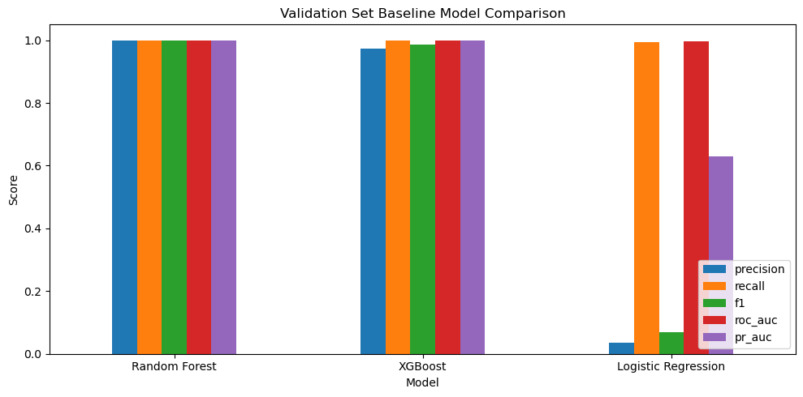

```python
plot_columns = ["precision", "recall", "f1", "roc_auc", "pr_auc"]

validation_results_df.set_index("model")[plot_columns].plot(kind="bar", figsize=(10, 5))
plt.title("Validation Set Baseline Model Comparison")
plt.xlabel("Model")
plt.ylabel("Score")
plt.xticks(rotation=0)
plt.ylim(0, 1.05)
plt.legend(loc="lower right")
plt.tight_layout()
plt.show()
```

**Validation comparison guidance:** Higher recall means the model catches more fraud cases. Higher precision means fewer false alarms. F1-score balances precision and recall. PR-AUC is especially useful for rare fraud detection because it focuses on ranking the positive fraud class.

## 8. Select Strongest Baseline Model

The strongest baseline model is selected using validation PR-AUC, with recall and F1-score used as tie-breakers inside the reusable selection utility. This is baseline selection only; the final supervised model will be chosen after tuning in notebook 03.

```python
best_model_name = select_best_model(validation_results_df, metric="pr_auc")
best_pipeline = fitted_models[best_model_name]

print(f"Strongest baseline model: {best_model_name}")
print("Selection criterion: validation PR-AUC, then recall, then F1-score")
```

```
Strongest baseline model: Random Forest
Selection criterion: validation PR-AUC, then recall, then F1-score
```

## 9. Baseline Holdout Test Sanity Check

The unchanged test set is evaluated only after selecting the strongest baseline from validation results. This is a holdout sanity check for the baseline notebook, not final production model evaluation.

```python
print_evaluation_report(best_pipeline, X_test, y_test, threshold=0.5)

holdout_test_metrics = evaluate_binary_classifier(
    best_pipeline,
    X_test,
    y_test,
    model_name=f"{best_model_name} (Baseline Holdout Test)",
    threshold=0.5,
)

final_test_metrics_df = pd.DataFrame([holdout_test_metrics])
REPORTS_DIR.mkdir(parents=True, exist_ok=True)
final_test_metrics_df.to_csv(FINAL_TEST_EVALUATION_PATH, index=False)
print(f"Saved baseline holdout evaluation table to: {FINAL_TEST_EVALUATION_PATH}")

final_test_metrics_df
```

```
              precision    recall  f1-score   support

           0       1.00      1.00      1.00   1270881
           1       1.00      1.00      1.00      1643

    accuracy                           1.00   1272524
   macro avg       1.00      1.00      1.00   1272524
weighted avg       1.00      1.00      1.00   1272524

Confusion matrix:
[[1270879       2]
 [      4    1639]]
Saved baseline holdout evaluation table to: d:\cs s1 26\基于深度学习的交易欺诈检测与智能风控系统\transaction-fraud-detection-system\reports\final_test_evaluation.csv
```

|  | model | accuracy | precision | recall | f1 | roc_auc | pr_auc | average_precision | tn | fp | fn | tp |
| --- | --- | --- | --- | --- | --- | --- | --- | --- | --- | --- | --- | --- |
| 0 | Random Forest (Baseline Holdout Test) | 1.0000 | 0.9988 | 0.9976 | 0.9982 | 0.9998 | 0.9987 | 0.9987 | 1270879 | 2 | 4 | 1639 |

**Leakage and interpretation note:** There is no obvious pipeline-level data leakage because preprocessing is inside the sklearn `Pipeline`, sampling is applied only to the training set, validation is used for model selection, and the test set is used only once as a holdout sanity check. Very high performance should still be interpreted carefully because PaySim is a synthetic dataset and balance-related fields provide very strong fraud signals.

## 10. Save Selected Baseline Pipeline

The saved object contains both the fitted preprocessor and the fitted baseline model. It can be loaded later for comparison, prediction experiments, and risk scoring preparation.

```python
MODEL_OUTPUT_PATH.parent.mkdir(parents=True, exist_ok=True)
joblib.dump(best_pipeline, MODEL_OUTPUT_PATH)

print(f"Saved selected baseline model pipeline to: {MODEL_OUTPUT_PATH}")
```

```
Saved selected baseline model pipeline to: d:\cs s1 26\基于深度学习的交易欺诈检测与智能风控系统\transaction-fraud-detection-system\models\ml\selected_model.pkl
```

## 11. Final Observations

- Reusable project code from `src/` now handles preprocessing, model pipelines, validation evaluation, and baseline selection.
- Logistic Regression, Random Forest, and XGBoost were compared as supervised baseline models.
- Validation metrics were used for baseline model comparison; the test set was not used for choosing the strongest baseline.
- Sampling was applied only to the training set for runtime efficiency.
- The strongest baseline model should not be treated as the final supervised model. Final supervised model selection will happen after tuning in notebook 03.

### Next Step

The next notebook will focus on hyperparameter tuning and model selection in `03_financial_ml_tuning_and_model_selection.ipynb`.

In this notebook, Logistic Regression, Random Forest, and XGBoost were compared as baseline supervised learning models. The best-performing model in this notebook should be interpreted as the strongest baseline model, not the final supervised model.

The next stage will tune the candidate model families and compare their tuned validation performance before selecting the final supervised ML model.

After supervised model tuning, the project will build the Autoencoder anomaly detection module in `04_financial_autoencoder_experiment.ipynb` as a supplementary risk signal.

The integrated risk scoring system will be developed later in `05_financial_risk_scoring_and_dashboard_prep.ipynb`, combining supervised fraud probability, Autoencoder anomaly signals, and business rules.

### Limitation Note

This PaySim V1 system is better described as a post-transaction fraud detection and risk monitoring system because it uses balance-related fields such as `newbalanceOrig` and `newbalanceDest`. For real-time pre-transaction fraud prevention, post-transaction balance fields would need to be removed or replaced with features available before transaction execution.